```python
import numpy as np
import matplotlib.pyplot as plt
from pprint import PrettyPrinter


seed = 800770097
rng = np.random.default_rng(seed = seed)
```

# Sculare tuo nonno a Las Vegas: una simulazione

Premetto che non ho idea di quanto questo gioco sia diffuso. Spero non sia troppo locale. Di sicuro nella mia città del sud Italia, a Natale, va forte. Il gioco si chiama *Las Vegas* ed è una variante di merda del poker tradizionale. Le regole le trovate qui.

Brevemente. Si gioca con un mazzo di carte francesi da 52 carte. Si distribuiscono 5 carte per giocatore e 5 carte per il banco. Per ricevere le carte si paga un puntata obbligatoria, che serve a riempire il piattino iniziale. I giocatori guardano le carte che hanno ricevuto, e vengono scoperte un tot di carte del banco. I giocatori scartano le carte con lo stesso valore numerico delle carte scoperte dal banco. A questo punto parte un giro di puntate, check, fold e tutta la solita tiritera, come in una partita di poker. Rinse and repeat, fin quando tutte le carte del banco sono scoperte. Se un giocatore rimane senza carte vince tutto il piattino--in questo caso si dice che ha fatto "Las Vegas". Altrimenti, i giocatori mostrano le carte dalla loro mano, e vincono i giocatori che hanno realizzato il punteggio più basso ed il punteggio più alto (50/50 se i vincitori sono due). Tutte le figure (Jack, Queen, King) valgono 10 punti. Sul wiki riportano una fantomatica regola per cui tutti gli assi oltre il primo valgono 11--personalmente non l'ho mai sentita, quindi qui facciamo come non esista.

In questo notebook simuleremo tanti giochi semplificati di Las Vegas e proveremo a tirare fuori dei numeri utili a valutare l'andamento di una partita, nella speranza di riuscire a vincere almeno contro tuo nonno ubriaco dal cenone.

Simulare il mazzo di carte è facile. Dal momento che questo gioco è una merda, non abbiamo bisogno di tener conto del seme delle carte:

```python
deck = np.array([i for i in range(1, 14) for j in range(4)])
deck
```

```
array([ 1,  1,  1,  1,  2,  2,  2,  2,  3,  3,  3,  3,  4,  4,  4,  4,  5,
        5,  5,  5,  6,  6,  6,  6,  7,  7,  7,  7,  8,  8,  8,  8,  9,  9,
        9,  9, 10, 10, 10, 10, 11, 11, 11, 11, 12, 12, 12, 12, 13, 13, 13,
       13])
```

Mescoliamo il mazzo. Già che ci siamo proviamo a pescare una mano:

```python
rng.shuffle(deck)
deck[:5]
```

```
array([ 1,  9,  2,  9, 10])
```

Distribuiamo le carte ai giocatori, che supporremmo essere 5, e mettiamo da parte le carte del mazzo rimanenti.

```python
num_players = 5
starting_hands, rest_of_deck = deck[:5 * num_players], deck[5 * num_players:]
```

I valori numerici delle carte nelle mani dei cinque giocatori sono questi:

```python
starting_hands = starting_hands.reshape(num_players, 5)
starting_hands
```

```
array([[ 1,  9,  2,  9, 10],
       [10,  7,  7, 11,  5],
       [ 3,  7,  7,  6,  1],
       [13,  3, 10,  1,  4],
       [ 6,  2, 12, 11,  5]])
```

Nel mazzo abbiamo ancora queste carte:

```python
rest_of_deck
```

```
array([ 3,  9,  8,  9, 12,  1,  6, 10,  5,  8,  4,  8, 12,  4,  6,  8, 12,
       11,  2,  2, 13,  3,  4, 13,  5, 13, 11])
```

Peschiamo le carte del banco. Tutte le carte del banco devono essere diverse. Usiamo un trucchetto per scartare i doppioni, se presenti:

```python
# > 2024
# > i set di python ancora non preservano l'ordine
u, ind = np.unique(rest_of_deck, return_index=True)
dealer = u[np.argsort(ind)][:5]
dealer
```

```
array([ 3,  9,  8, 12,  1])
```

Qui simuliamo la versione più semplice possibile del gioco. Tutti i giocatori sono degli imbecilli, sono onesti, non si ritirano, non bluffano, non fanno uso delle informazioni date dal gioco (le carte nelle mani degli altri giocatori, le carte scoperte di volta in volta dal banco). Giocano fino alla fine, scartando le carte chiamate di volta in volta dal banco. Al termine del gioco le mani dei giocatori sono:

```python
player_hands = list(map(
    lambda hand: hand[~np.isin(hand, dealer)],
    starting_hands,
))
player_hands
```

```
[array([ 2, 10]),
 array([10,  7,  7, 11,  5]),
 array([7, 7, 6]),
 array([13, 10,  4]),
 array([ 6,  2, 11,  5])]
```

Calcolare il punteggio totalizzato da un certo giocatore è facile: basta sommare i valori numerici delle carte nella mano, badando a contare le figure con un punteggio di 10. Per esempio, il punteggio totalizzato dal primo giocatore è:

```python
player_id = 0
np.sum(np.clip(player_hands[player_id], a_min = None, a_max = 10))
```

```
12
```

Calcoliamo i punteggi per tutti i giocatori:

```python
def compute_scores(hands):
    return list(map(
        lambda hand: np.sum(np.clip(hand, a_min = None, a_max = 10)),
        hands
    ))

player_scores = compute_scores(player_hands)
player_scores
```

```
[12, 39, 20, 24, 23]
```

Vediamo chi ha vinto. Innanzitutto dobbiamo assicurarci se qualcuno ha fatto Las Vegas, ossia se ci sono giocatori senza più carte in mano.

```python
0 in player_scores
```

```
False
```

Se tutti i giocatori hanno ancora carte in mano, vincono quelli con il punteggio più alto e quelli con il punteggio più basso. I punteggi che hanno vinto questa partita sono:

```python
winning_scores = sorted(player_scores)[::num_players - 1]
winning_scores
```

```
[12, 39]
```

Mettiamo tutto insieme e simuliamo un tot di partite:

```python
def compute_scores(hands):
    return list(map(
        lambda hand: np.sum(np.clip(hand, a_min = None, a_max = 10)),
        hands
    ))

def winning_scores(player_scores):
    if 0 in player_scores: return [0] * player_scores.count(0)
    return sorted(player_scores)[::num_players - 1]

def play_a_game(num_players, rng):
    deck = np.array([i for i in range(1, 14) for j in range(4)])
    rng.shuffle(deck)
    starting_hands, rest_of_deck = deck[:5 * num_players], deck[5 * num_players:]
    starting_hands = starting_hands.reshape(num_players, 5)
    u, ind = np.unique(rest_of_deck, return_index=True)
    dealer = u[np.argsort(ind)][:5]
    player_hands = list(map(
        lambda hand: hand[~np.isin(hand, dealer)],
        starting_hands,
    ))
    return compute_scores(player_hands)
```

```python
num_games = 100000
scores = []
wscores = []
for i in range(num_games):
    ss = play_a_game(5, rng)
    scores.extend(ss)
    wscores.extend(winning_scores(ss))
```

La prima cosa che vogliamo capire meglio è la distribuzione dei punteggi a fine partita.

```python
max_score = 50
min_score = 0
bins = np.arange(min_score, max_score + 2, 1)
wscore_counts, _ = np.histogram(wscores, bins=bins)
score_counts, _ = np.histogram(scores, bins=bins)
```

Qui in arancione riportiamo un istogramma dei punteggi a fine partita realizzati dai giocatori. In blu riportiamo invece un istogramma dei punteggi realizzati dai giocatori che hanno vinto una partita.

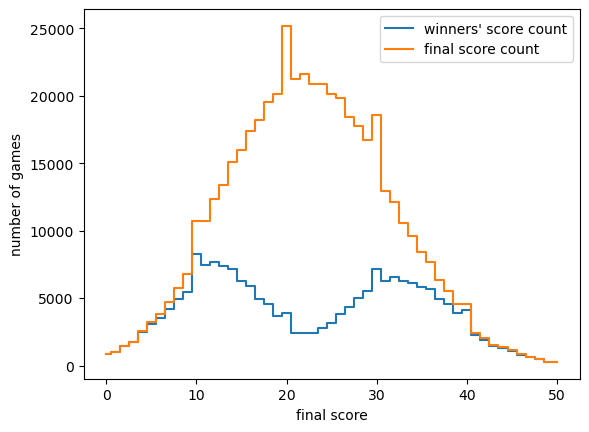

```python
plt.step(bins[:-1], wscore_counts, where="mid", label="winners' score count")
plt.step(bins[:-1], score_counts, where="mid", label="final score count")
plt.legend()
plt.ylabel("number of games")
plt.xlabel("final score")
plt.show()
```

Il punteggi con cui una partita viene vinta più comunemente sono un poco sopra il 10 e un poco sopra il 30. Attenzione però, questi punteggi non sono strettamente punteggi "buoni". Normalizziamo le probabilità per la frequenza del punteggio a fine partita (probabilità condizionata). In altre parole, quantifichiamo la frazione di partite vinte, dato il punteggio della nostra mano a fine partita.

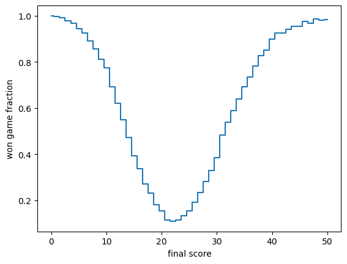

```python
plt.step(bins[:-1], wscore_counts / score_counts, where="mid")
plt.ylabel("won game fraction")
plt.xlabel("final score")
plt.show()
```

Qui sotto abbiamo i valori numerici dell'istogramma appena sopra.

```python
pp = PrettyPrinter()
pp.pprint({s: round(p,2) for s, p in zip(bins, wscore_counts / score_counts)})
```

```
{0: 1.0,
 1: 1.0,
 2: 0.99,
 3: 0.98,
 4: 0.97,
 5: 0.94,
 6: 0.93,
 7: 0.89,
 8: 0.86,
 9: 0.81,
 10: 0.77,
 11: 0.69,
 12: 0.62,
 13: 0.55,
 14: 0.47,
```

[output cut: 36 more lines]

Qualche esempio su come leggere questa tabella:

- Abbiamo vinto il $\approx95\%$ delle simulazioni in cui ci siamo trovati a fine partita con un punteggio di 5 o 45.
- Abbiamo vinto il $\approx75\%$ delle simulazioni in cui ci siamo trovati a fine partita con un punteggio di 10 o 36.
- Abbiamo vinto il $\approx50\%$ delle simulazioni in cui ci siamo trovati a fine partita con un punteggio di 31 o 14.

## Mano iniziale

Il momento più delicato del gioco è sicuramente quello della prima puntata. Abbiamo ricevuto una mano e ci troviamo a valutare quanto buona questa sia. Se la mano è buona, è molto probabile che vorremo continuare a giocare. Se la mano è meh, potremmo volerci ritirare, limitando le perdite alla puntata di entrata.

Torniamo alla partita simulata all'inizio di questo notebook. Le mani e i punteggi dei giocatori a fine partita erano:

```python
player_hands
```

```
[array([ 2, 10]),
 array([10,  7,  7, 11,  5]),
 array([7, 7, 6]),
 array([13, 10,  4]),
 array([ 6,  2, 11,  5])]
```

```python
player_scores
```

```
[12, 39, 20, 24, 23]
```

Per analizzare le mani iniziali dei giocatori che hanno vinto la partita per prima cosa dobbiamo identificare i vincitori.

```python
wargs = np.argwhere(np.isin(player_scores, winning_scores(player_scores))).T[0]
wargs
```

```
array([0, 1])
```

Ora che sappiamo chi ha vinto, possiamo dare un occhio alle carte che ha ricevuto ad inizio partita:

```python
winners_start_hands = [starting_hands[i] for i in wargs]
winners_start_hands
```

```
[array([ 1,  9,  2,  9, 10]), array([10,  7,  7, 11,  5])]
```

Calcoliamo il punteggio di queste mani iniziali:

```python
compute_scores(winners_start_hands)
```

```
[31, 39]
```

Il giocatore col punteggio più alto non era in possesso di nessuna delle carte rivelate dal banco. Il valore della mano iniziale dell'altro vincitore era alto, ma è comunque riuscito a totalizzare il punteggio più basso scartando un doppio 9 dalla sua mano.

Per tracciare questa "meccanica" usiamo una metrica che chiameremo molteplicità. Definiamo la molteplicità di una mano come la differenza tra 5 e il numero di carte uniche nella stessa mano:

```python
list(map(lambda h: len(h) - len(set(h)), starting_hands))
```

```
[1, 1, 1, 0, 0]
```

Rimettiamo tutto insieme (con qualche modifica) e rilanciamo le simulazioni, questa volta tenendo traccia del punteggio e della molteplicità delle mani iniziali.

```python
def winners(player_scores):
    if 0 in player_scores:
        ws = [0] * player_scores.count(0)
    ws = sorted(player_scores)[::num_players - 1]
    wargs = np.argwhere(np.isin(player_scores, ws)).T[0]
    return ws, wargs

def multiplicity(hands):
    return list(map(lambda h: len(h) - len(set(h)), hands))

def play_a_game(num_players, rng):
    deck = np.array([i for i in range(1, 14) for j in range(4)])
    rng.shuffle(deck)
    starting_hands, rest_of_deck = deck[:5 * num_players], deck[5 * num_players:]
    starting_hands = starting_hands.reshape(num_players, 5)
    u, ind = np.unique(rest_of_deck, return_index=True)
    dealer = u[np.argsort(ind)][:5]
    player_hands = list(map(
        lambda hand: hand[~np.isin(hand, dealer)],
        starting_hands,
    ))
    return player_hands, starting_hands
```

```python
num_games = 100000
start_scores = []
start_mults = []
winners_start_scores = []
winners_start_mults = []
for i in range(num_games):
    player_hands, starting_hands = play_a_game(num_players, rng)
    scores = compute_scores(starting_hands)
    wscores, wargs = winners(scores)
    winners_start_hands = [starting_hands[i] for i in wargs]

    winners_start_scores.extend(compute_scores(winners_start_hands))
    winners_start_mults.extend(multiplicity(winners_start_hands))
    start_scores.extend(scores)
    start_mults.extend(multiplicity(starting_hands))
```

Per prima cosa istogrammiamo la frequenza dei punteggi realizzati nelle mani iniziali, e quella dei punteggi realizzati nelle mani dei vincitori a inizio partita:

```python
max_score = 50
min_score = 0
bins = np.arange(min_score, max_score + 2, 1)
start_score_counts, _ = np.histogram(start_scores, bins=bins)
winners_start_score_counts, _ = np.histogram(winners_start_scores, bins=bins)
```

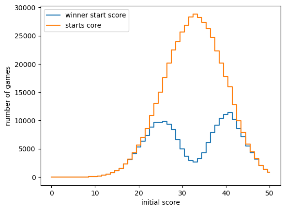

```python
plt.step(bins[:-1], winners_start_score_counts, where="mid", label="winner start score")
plt.step(bins[:-1], start_score_counts, where="mid", label="starts core")
plt.legend()
plt.ylabel("number of games")
plt.xlabel("initial score")
plt.show()
```

Il punteggio medio di una mano a inizio partita è tra 32 e 33. Questi sono anche i valori meno comuni osservati tra le mani iniziali dei giocatori che vinceranno la partita.

Plottiamo la frazione di partite vinte dato il punteggio della mano iniziale:

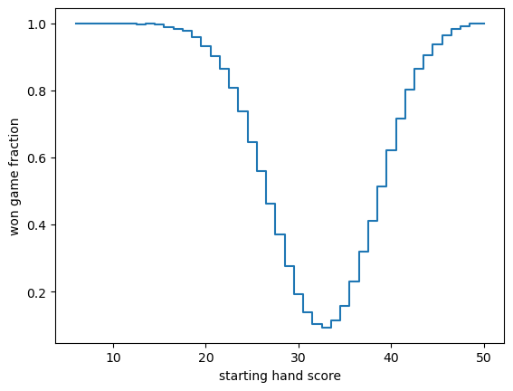

```python
with np.errstate(divide='ignore', invalid='ignore'):
    start_score_winning_prb = winners_start_score_counts / start_score_counts

plt.step(bins[6:-1], np.nan_to_num(start_score_winning_prb, nan=1)[6:], where="mid")
plt.ylabel("won game fraction")
plt.xlabel("starting hand score")
plt.show()
```

Ancora una volta, tabuliamo i valori numerici:

```python
pp = PrettyPrinter()
pp.pprint({s: round(p,2) for s, p in zip(bins[6:-1], np.nan_to_num(start_score_winning_prb, nan=1)[6:])})
```

```
{6: 1.0,
 7: 1.0,
 8: 1.0,
 9: 1.0,
 10: 1.0,
 11: 1.0,
 12: 1.0,
 13: 1.0,
 14: 1.0,
 15: 1.0,
 16: 0.99,
 17: 0.98,
 18: 0.98,
 19: 0.96,
 20: 0.93,
```

[output cut: 30 more lines]

Qualche esempio su come leggere questa tabella:

- Abbiamo vinto il $\approx95\%$ delle simulazioni in cui ci siamo partiti con una mano con un punteggio iniziale di 19 o 45.
- Abbiamo vinto il $\approx75\%$ delle simulazioni in cui ci siamo partiti con una mano con un punteggio iniziale di 24 o 41.
- Abbiamo vinto il $\approx50\%$ delle simulazioni in cui ci siamo partiti con una mano con un punteggio iniziale di 26 o 39.
- Le mani iniziali con valore tra 27 e 39 fanno spesso e volentieri cacare.

Finalmente diamo un'occhiata alla molteplicità delle mani iniziali.

```python
max_score = 5
min_score = 0
bins = np.arange(min_score, max_score + 2, 1)
start_mult_counts, _ = np.histogram(start_mults, bins=bins)
winners_start_mult_counts, _ = np.histogram(winners_start_mults, bins=bins)
```

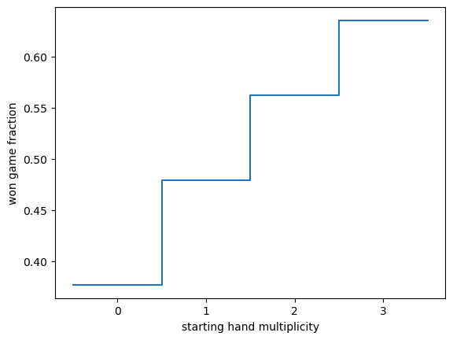

```python
with np.errstate(divide='ignore', invalid='ignore'):
    start_mult_winning_prb = winners_start_mult_counts / start_mult_counts

plt.step(bins[:-1]- 0.5, start_mult_winning_prb, where="post")
plt.xticks([0, 1, 2, 3])
plt.ylabel("won game fraction")
plt.xlabel("starting hand multiplicity")
plt.show()
```

A questo punto mi sono rotto di commentare ma nel dubbio, puoi credere nel cuore delle carte se la mano ha alta molteplicità.

E niente, spero sia utile a qualcuno. Tenete presente che il comportamento dei giocatori in questa simulazione è stato del tutto trascurato, starà a voi correggere il tiro alla luce dell'andamento della partita. Penso comunque sia un buon punto di partenza.